# Báo Cáo Phân Tích Môi Trường Sống và Sức Khỏe Hộ Gia Đình

Nhóm 5

2025-10-20

### **Chủ đề nghiên cứu:** Mối liên quan giữa điều kiện vệ sinh, nguồn nước, và sức khỏe của các thành viên trong hộ gia đình.

**Câu hỏi nghiên cứu:**

1. Mô tả tỷ lệ các hộ gia đình được tiếp cận với nguồn nước sạch và nhà tiêu hợp vệ sinh. Trực quan hóa sự chênh lệch về các chỉ số này giữa khu vực thành thị và nông thôn.
2. Kiểm định giả thuyết: Liệu các hộ gia đình sử dụng nguồn nước không an toàn có tỷ lệ trẻ em (< 5 tuổi) bị tiêu chảy cao hơn so với các hộ gia đình dùng nước sạch hay không?
3. Xây dựng mô hình hồi quy logistic để xác định các yếu tố kinh tế - xã hội (mức sống, trình độ học vấn của chủ hộ) dự đoán khả năng một hộ gia đình sở hữu nhà tiêu hợp vệ sinh.
4. Sự thay đổi của các vấn đề nghiên cứu trong vòng 20 năm qua (2000-2021) và dự báo sự thay đổi trong 10 năm tới.

**Mô tả số liệu:**

Bộ dữ liệu được lấy từ khảo sát `MICS6 (2021)`, `MICS5 (2013 -14)`, `MICS4 (2010 -11)`, `MICS3 (2006)`, `MICS2 (2000)` của UNICEF tại Việt Nam, bao gồm các thông tin về hộ gia đình, trẻ em và các yếu tố liên quan đến sức khỏe cộng đồng.

Các biến số chính được sử dụng

- Biến phụ thuộc:
  - `WS11`: Loại nhà vệ sinh của hộ gia đình.
  - `WS1`: Nguồn nước uống chính của hộ gia đình
  - `CA1`: Trẻ có bị tiêu chảy trong 2 tuần qua không.
- Biến độc lập:
  - `HH6`: Khu vực sinh sống
  - `windex5`: Mức sống kinh tế của hộ gia đình
  - `windex5r`: Mức sống kinh tế của hộ gia đình ở nông thôn
  - `windex5u`: Mức sống kinh tế của hộ gia đình ở thành thị
  - `helevel`: Trình độ học vấn của chủ hộ
  - `HC2`: Dân tộc chủ hộ
  - `HH5Y`: Năm tiến hành nghiên cứu

## **I. MỐI LIÊN QUAN GIỮA ĐIỀU KIỆN VỆ SINH, NGUỒN NƯỚC, VÀ SỨC KHỎE CỦA CÁC THÀNH VIÊN TRONG HỘ GIA ĐÌNH**

### **1. Kết quả làm sạch dữ liệu**

**Xử lý missing:**

Bảng 1. Tỷ lệ thiếu dữ liệu trong hh.sav

| HH1 | HH2 | HH6 | WS1 | WS11 | helevel | HC2 | windex5 | windex5r | windex5u | HH5Y |
| --- | --- | --- | --- | --- | --- | --- | --- | --- | --- | --- |
| 0 | 0 | 0 | 0 | 0 | 0 | 0 | 0 | 31.50685 | 68.49315 | 0 |

Bảng 2. Tỷ lệ thiếu dữ liệu trong ch.sav

| HH1 | HH2 | CA1 | UF10 |
| --- | --- | --- | --- |
| 0 | 0 | 0 | 0 |

**Tỷ lệ dữ liệu thiếu:** đa phần các biến không có dữ liệu thiếu

- **Hai biến có tỷ lệ thiếu cao:** `windex5r` (31.5%) và `windex5u` (68.49%) do áp dụng cho nhóm khu vực khác nhau.

**Cách xử lý:**

- Giữ nguyên giá trị trong `windex5r, windex5u`.

**Các biến mới đã được tạo:**

- Biến `diarrhea`: bằng 1 nếu trẻ trong hộ được báo cáo là bị tiêu chảy trong vòng 2 tuần trước khảo sát, bằng 0 nếu không bị.
- Biến `any_diarrhea`: bằng 1 nếu trong hộ có ít nhất một trẻ bị tiêu chảy, bằng 0 nếu không có.
- Biến `safe_water`: bằng 1 nếu nguồn nước sinh hoạt thuộc nhóm an toàn (nước máy, giếng khoan), bằng 0 nếu không thuộc nhóm an toàn (nước, sông, ao hồ).
- Biến `improved_sanitation`: bằng 1 nếu hộ có nhà tiêu hợp vệ sinh và bằng 0 nếu không có.

### **2. Thống kê mô tả và trực quan hóa**

Bảng 2. Tần số hộ có nước sạch

| safe_water | n | percent |
| --- | --- | --- |
| Không | 533 | 0.0398982 |
| Có | 12826 | 0.9601018 |

Bảng 3. Tần số hộ có nhà tiêu hợp vệ sinh

| improved_sanitation | n | percent |
| --- | --- | --- |
| Không | 2752 | 0.2060034 |
| Có | 10607 | 0.7939966 |

*Nhận xét:* Khoảng 96% hộ sử dụng nguồn nước sạch và khoảng 79% hộ có nhà tiêu hợp vệ sinh, cho thấy điều kiện vệ sinh nhìn chung khá tốt.

#### *Biểu đồ tròn tỷ lệ*

##### Tỷ lệ hộ sử dụng nước sạch

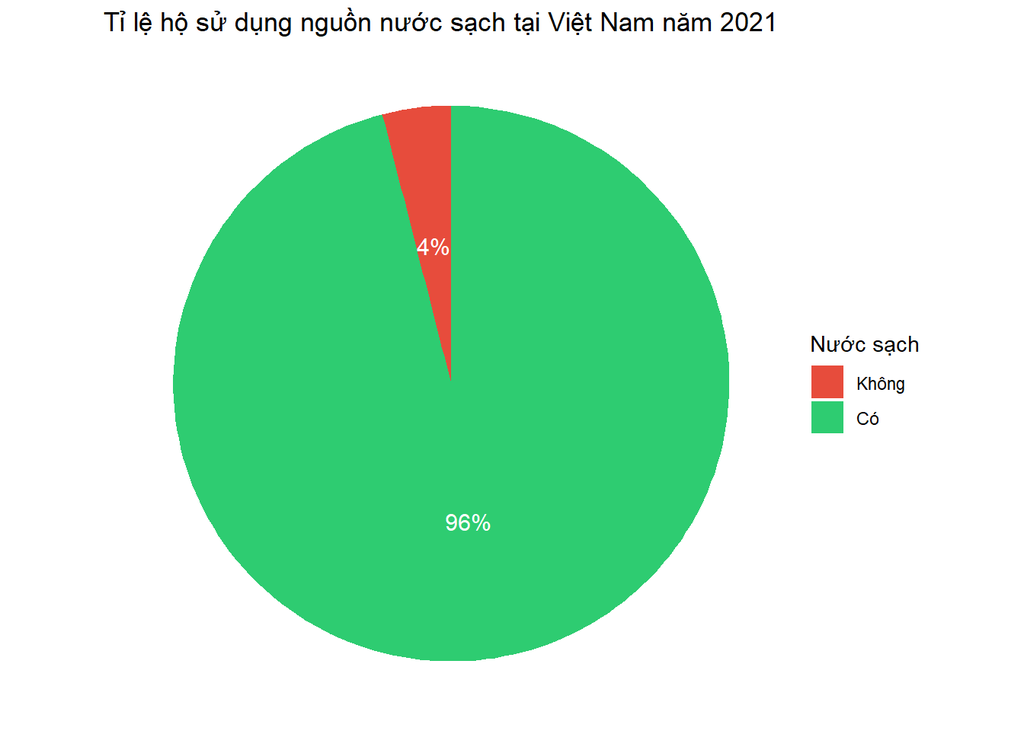

**Nhận xét:** Tỷ lệ hộ có nguồn nước sạch là 96% cho thấy đa số hộ gia đình sử dụng nước sạch, cho thấy hạ tầng cấp nước khá tốt.

##### Tỷ lệ hộ có nhà tiêu hợp vệ sinh

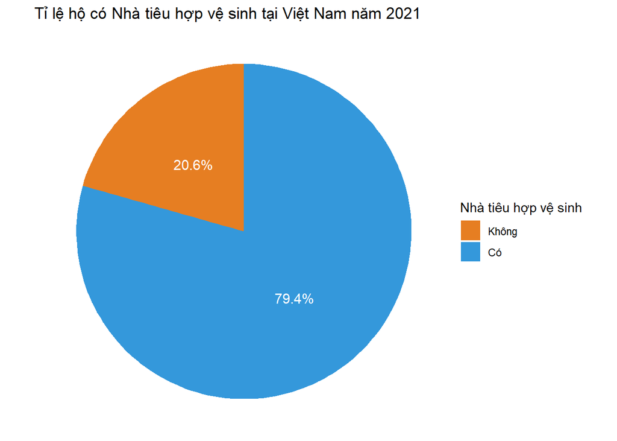

**Nhận xét:** Tỷ lệ hộ có nhà tiêu hợp vệ sinh là 79.4%, vẫn còn 20.6% hộ chưa có nhà tiêu đạt chuẩn, tiềm ẩn nguy cơ ô nhiễm.

#### *Biểu đồ cột so sánh theo khu vực*

##### Nước sạch

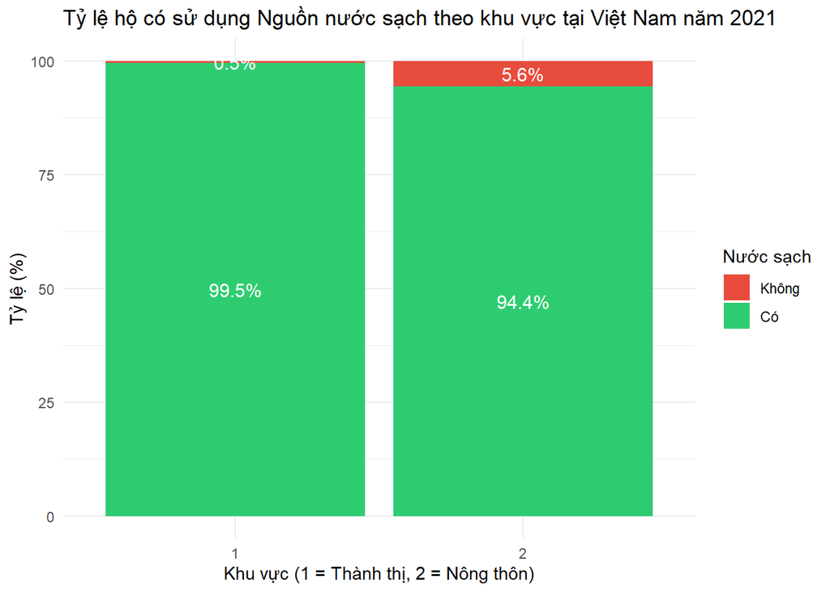

**Nhận xét:** Việt Nam đạt tỷ lệ hộ sử dụng nước sạch rất cao, đặc biệt tại khu vực thành thị. Tuy nhiên, chênh lệch giữa nông thôn và thành thị (5%) cho thấy vẫn cần tiếp tục đầu tư và cải thiện hệ thống cấp nước ở nông thôn để đảm bảo công bằng trong tiếp cận nguồn nước sạch.

##### Nhà tiêu hợp vệ sinh

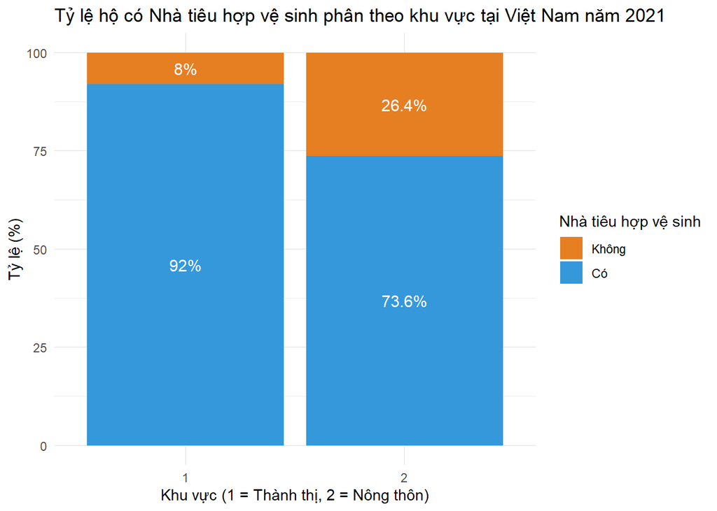

**Nhận xét:** Khu vực thành thị có điều kiện vệ sinh tốt hơn nhiều so với nông thôn. Tỷ lệ hộ có nhà tiêu hợp vệ sinh ở nông thôn thấp hơn 18.4% so với thành thị.

### **3. Kết quả phân tích mối liên quan**

#### **3.1. Kiểm định Chi-squared**

Bảng 4. Bảng chéo giữa Nước sạch và Tiêu chảy

| hh6_clean.safe_water | hh6_clean.any_diarrhea | Freq |
| --- | --- | --- |
| 0 | 0 | 190 |
| 1 | 0 | 3019 |
| 0 | 1 | 30 |
| 1 | 1 | 280 |

Bảng 5. Kết quả kiểm định Chi-squared

```
##
##  Pearson's Chi-squared test with Yates' continuity correction
##
## data:  hh6_clean$safe_water and hh6_clean$any_diarrhea
## X-squared = 6.1807, df = 1, p-value = 0.01291
```

**Nhận xét:** p = 0.01291 < 0.05 -> Có mối liên hệ thống kê có ý nghĩa giữa việc sử dụng nước sạch và tình trạng tiêu chảy ở trẻ em trong mẫu khảo sát này.

#### **3.2. Phân tích hồi quy logistic**

#### **3.2.1. Phân tích mối liên quan giữa yếu tố về điều kiện kinh tế và học vấn với khả năng có nhà tiêu hợp vệ sinh.**

```
##
## Call:
## glm(formula = improved_sanitation ~ windex5_factor + helevel_factor +
##     HH6 + HC2, family = binomial, data = hh6_clean)
##
## Coefficients:
##                                 Estimate Std. Error z value Pr(>|z|)
## (Intercept)                      0.31778    0.15874   2.002 0.045300 *
## windex5_factor_Nhóm_2            1.35965    0.06831  19.904  < 2e-16 ***
## windex5_factor_Nhóm_3            2.12944    0.10037  21.217  < 2e-16 ***
## windex5_factor_Nhóm_4            2.58068    0.13091  19.714  < 2e-16 ***
## windex5_factorGiàu nhất          3.27776    0.19394  16.901  < 2e-16 ***
## helevel_factor_Tiểu_học          0.31367    0.07060   4.443 8.87e-06 ***
## helevel_factor_THCS              0.65680    0.07288   9.012  < 2e-16 ***
## helevel_factor_THPT              0.77448    0.09706   7.980 1.47e-15 ***
## helevel_factor_Trung cấp         0.78780    0.20424   3.857 0.000115 ***
## helevel_factor_Cao_đẳng/Đại_học  0.82302    0.14941   5.508 3.62e-08 ***
## helevel_factor_Không_biết        0.02644    0.49131   0.054 0.957086
## HH6                             -0.11987    0.07307  -1.640 0.100921
## HC2                             -0.09502    0.01545  -6.150 7.77e-10 ***
## ---
## Signif. codes:  0 '***' 0.001 '**' 0.01 '*' 0.05 '.' 0.1 ' ' 1
##
## (Dispersion parameter for binomial family taken to be 1)
##
##     Null deviance: 13589  on 13358  degrees of freedom
## Residual deviance: 10396  on 13346  degrees of freedom
## AIC: 10422
##
## Number of Fisher Scoring iterations: 6
```

#### **3.2.2. Phân tích mối liên quan giữa yếu tố về điều kiện kinh tế - xã hội (ở thành thị hoặc nông thôn) và học vấn với khả năng có nhà tiêu hợp vệ sinh.**

##### Điều kiện ở nông thôn

```
##
## Call:
## glm(formula = improved_sanitation ~ windex5r_factor + helevel_factor +
##     HC2, family = binomial, data = hh6_clean)
##
## Coefficients:
##                                 Estimate Std. Error z value Pr(>|z|)
## (Intercept)                     -0.16761    0.08973  -1.868 0.061782 .
## windex5r_factor_Nhóm_2           0.98705    0.07068  13.965  < 2e-16 ***
## windex5r_factor_Nhóm_3           2.20628    0.10804  20.421  < 2e-16 ***
## windex5r_factor_Nhóm_4           2.59270    0.14241  18.206  < 2e-16 ***
## windex5r_factorGiàu nhất         3.42409    0.21934  15.611  < 2e-16 ***
## helevel_factor_Tiểu_học          0.29988    0.07558   3.968 7.25e-05 ***
## helevel_factor_THCS              0.67630    0.07882   8.580  < 2e-16 ***
## helevel_factor_THPT              0.91789    0.11004   8.342  < 2e-16 ***
## helevel_factor_Trung cấp         0.87448    0.24288   3.601 0.000318 ***
## helevel_factor_Cao_đẳng/Đại_học  0.73569    0.18567   3.962 7.42e-05 ***
## helevel_factor_Không_biết       -0.55215    0.53843  -1.025 0.305135
## HC2                             -0.06756    0.01714  -3.941 8.11e-05 ***
## ---
## Signif. codes:  0 '***' 0.001 '**' 0.01 '*' 0.05 '.' 0.1 ' ' 1
##
## (Dispersion parameter for binomial family taken to be 1)
##
##     Null deviance: 10563.6  on 9149  degrees of freedom
## Residual deviance:  8250.5  on 9138  degrees of freedom
##   (4209 observations deleted due to missingness)
## AIC: 8274.5
##
## Number of Fisher Scoring iterations: 6
```

**Nhận xét:** Ở khu vực nông thôn, mức sống và học vấn vẫn là hai yếu tố có ảnh hưởng rõ rệt nhất đến khả năng có nhà tiêu hợp vệ sinh.

- `windex5r`, `helevel`, `HC2` có ý nghĩa thống kê rất mạnh (p < 0.001).

##### Điều kiện ở thành thị

```
##
## Call:
## glm(formula = improved_sanitation ~ windex5u_factor + helevel_factor +
##     HC2, family = binomial, data = hh6_clean)
##
## Coefficients:
##                                  Estimate Std. Error z value Pr(>|z|)
## (Intercept)                       1.44038    0.23300   6.182 6.34e-10 ***
## windex5u_factor_Nhóm_2            1.07186    0.16178   6.625 3.46e-11 ***
## windex5u_factor_Nhóm_3            1.70390    0.21527   7.915 2.47e-15 ***
## windex5u_factor_Nhóm_4            1.95202    0.26430   7.386 1.52e-13 ***
## windex5u_factorGiàu nhất          2.38659    0.34903   6.838 8.05e-12 ***
## helevel_factor_Tiểu_học           0.05230    0.23227   0.225   0.8218
## helevel_factor_THCS               0.12865    0.22564   0.570   0.5686
## helevel_factor_THPT               0.17593    0.24873   0.707   0.4794
## helevel_factor_Trung cấp          0.52131    0.40712   1.280   0.2004
## helevel_factor_Cao_đẳng/Đại_học   0.65923    0.30330   2.174   0.0297 *
## helevel_factor_Không_biết        12.49157  279.00436   0.045   0.9643
## HC2                              -0.06798    0.04934  -1.378   0.1683
## ---
## Signif. codes:  0 '***' 0.001 '**' 0.01 '*' 0.05 '.' 0.1 ' ' 1
##
## (Dispersion parameter for binomial family taken to be 1)
##
##     Null deviance: 2343.2  on 4208  degrees of freedom
## Residual deviance: 2059.3  on 4197  degrees of freedom
##   (9150 observations deleted due to missingness)
## AIC: 2083.3
##
## Number of Fisher Scoring iterations: 13
```

## **II. SỰ THAY ĐỔI CỦA CÁC VẤN ĐỀ TRONG 20 NĂM**

## **(2000-2021)**

### **1. Xu hướng và Dự báo Chuỗi thời gian (2000-2021)**

#### Trực quan hóa Xu hướng Tỷ lệ Tiếp cận nước sạch và Nhà tiêu hợp vệ sinh

##### Nguồn nước sạch

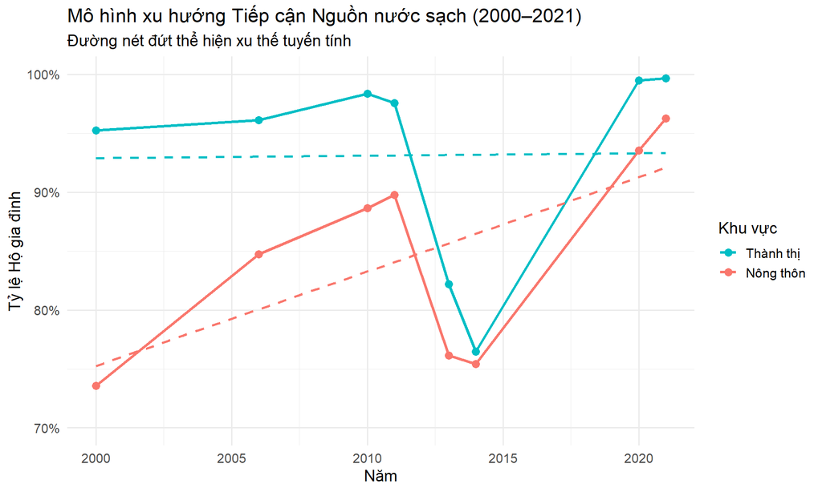

**Nhận xét:**

Khu vực thành thị: Tỷ lệ hộ gia đình có nguồn nước hợp vệ sinh duy trì ở mức cao (~95–100%) từ năm 2000 đến 2010.

- Tuy nhiên, năm 2013-2014 sụt giảm đột ngột nhưng sau đó phục hồi lại lên gần 100% vào năm 2021. **Lý do** cho vấn đề sụt giảm đột ngột này là vì sự thay đổi trong tiêu chuẩn xét nguồn nước sạch, không công nhận nước đóng chai phù hợp để uống.

→ Xu hướng tổng thể: cao, ổn định, có một giai đoạn biến động giữa kỳ.

Khu vực nông thôn: Xuất phát từ mức thấp hơn (~75% năm 2000), tăng dần đến ~90% năm 2010.

→ Xu hướng tổng thể: cải thiện mạnh mẽ, dù có một giai đoạn gián đoạn tạm thời.

**Kết luận:** Đường hồi quy tuyến tính (linear trendline) của cả hai khu vực đều có hệ số góc dương, phản ánh xu hướng tăng dài hạn của tỷ lệ hộ tiếp cận nước hợp vệ sinh thể hiện xu hướng cải thiện bền vững, trong đó độ dốc ở nông thôn cao hơn, phản ánh tốc độ tiến bộ nhanh hơn

##### Nhà tiêu Hợp vệ sinh

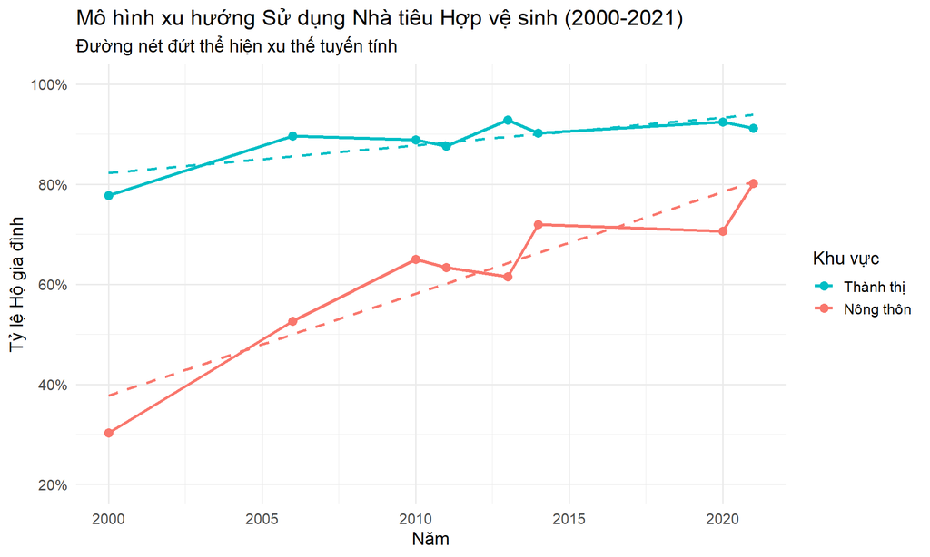

**Nhận xét:**

- Biến động nhỏ quanh giai đoạn 2010–2015, nhưng nhìn chung ổn định.

→ Xu hướng tổng thể: tăng chậm nhưng bền vững, hiện đã đạt mức cao.

Khu vực nông thôn: Từ ~30% (2000) tăng mạnh lên ~80% (2021).

- Dù có vài năm chững lại (khoảng 2010–2015), xu hướng dài hạn vẫn rõ ràng là tăng nhanh.

→ Xu hướng tổng thể: cải thiện đáng kể, nhưng vẫn chưa bắt kịp thành thị.

**Kết luận:** Khoảng cách giữa thành thị và nông thôn trong sử dụng nhà tiêu hợp vệ sinh đã thu hẹp đáng kể, phản ánh hiệu quả của các chương trình vệ sinh nông thôn. Đườngtuyến tính đi lên cho thấyxu hướng cải thiện ổn định**,** với nông thôn tiến bộ nhanh hơn.

________________

#### **Mô hình hóa và Dự báo bằng ARIMA**

Do dữ liệu được thu thập không đều -> Sử dụng phương pháp **nội suy tuyến tính** để tạo chuỗi thời gian hàng năm, sau đó áp dụng mô hình `auto.arima` để tìm ra mô hình phù hợp nhất và dự báo cho 10 năm tới.

Bảng 7. Kết quả Mô hình ARIMA

##### Nguồn nước - Nông thôn

```
##
## **Mô hình ARIMA cho Tỷ lệ  sử dụng Nguồn nước sạch - Nông thôn**
## Series: ts_object
## ARIMA(2,0,0) with non-zero mean
##
## Coefficients:
##          ar1      ar2    mean
##       1.5955  -0.7807  0.8379
## s.e.  0.1290   0.1392  0.0225
##
## sigma^2 = 0.0004484:  log likelihood = 53.45
## AIC=-98.9   AICc=-96.55   BIC=-94.54
##
## Training set error measures:
##                        ME      RMSE        MAE        MPE     MAPE      MASE
## Training set 0.0007891903 0.0196785 0.01368366 0.03731916 1.661774 0.5587208
##                   ACF1
## Training set 0.1448319
```

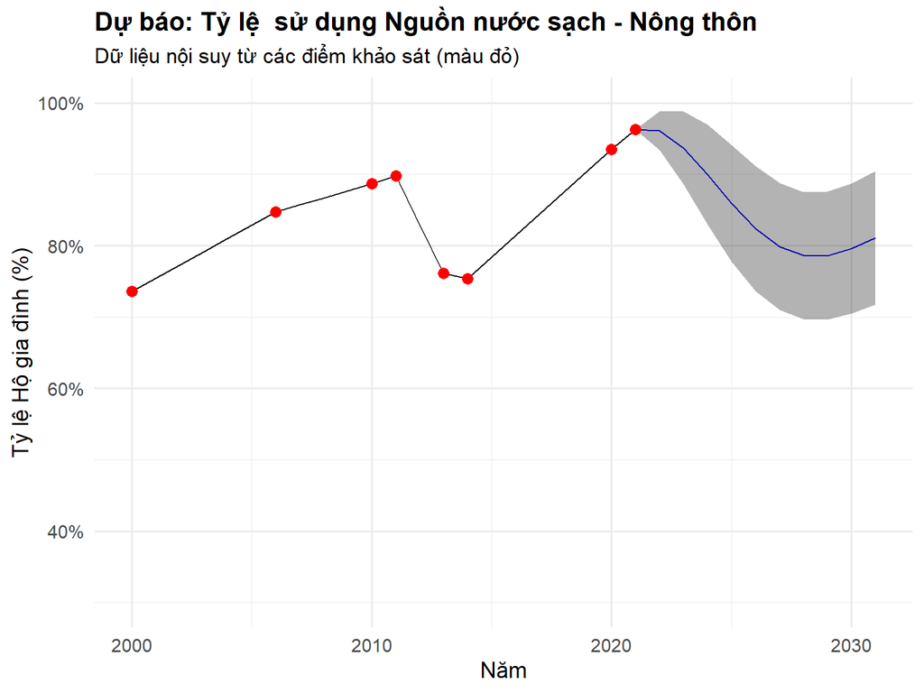

**Diễn giải kết quả:** Mô hình ARIMA(2,0,0)

##### Nhà tiêu - Nông thôn

```
##
## **Mô hình ARIMA cho Tỷ lệ tiếp cận Nhà tiêu Hợp vệ sinh - Nông thôn**
## Series: ts_object
## ARIMA(0,1,0) with drift
##
## Coefficients:
##        drift
##       0.0238
## s.e.  0.0069
##
## sigma^2 = 0.001047:  log likelihood = 42.76
## AIC=-81.53   AICc=-80.86   BIC=-79.44
##
## Training set error measures:
##                        ME       RMSE        MAE       MPE     MAPE      MASE
## Training set 1.268314e-05 0.03085072 0.02388883 0.2354046 3.780065 0.8409385
##                      ACF1
## Training set 0.0003986401
```

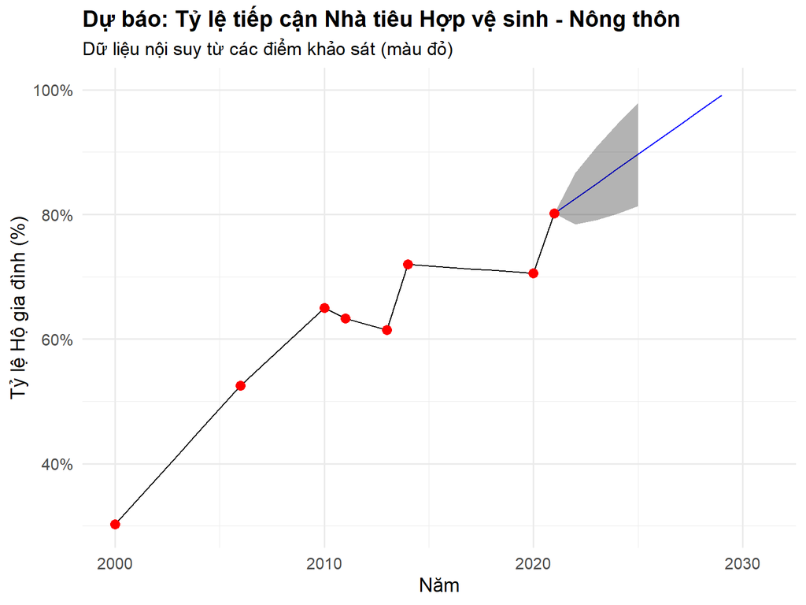

**Diễn giải kết quả:**Mô hình ARIMA(0,1,0) với drift

- Xu hướng tăng ổn định và liên tục sau 2021.
- Độ trôi (drift) dương 0.0238 → cho thấy mức tăng hàng năm ổn định.
- Giá trị RMSE = 0.0308 tuy cao hơn nhóm nước sạch nhưng vẫn trong mức chấp nhận được, phản ánh dữ liệu có dao động nhẹ nhưng xu hướng ổn định

→ Dự báo: đến 2030, tỷ lệ hộ nông thôn dùng nhà tiêu hợp vệ sinh có thể vượt 90–95%.

##### Nguồn nước - Thành thị

```
##
## **Mô hình ARIMA cho Tỷ lệ sử dụng Nguồn nước sạch - Thành thị**
## Series: ts_object
## ARIMA(2,0,0) with non-zero mean
##
## Coefficients:
##          ar1      ar2    mean
##       1.5118  -0.7578  0.9295
## s.e.  0.1193   0.1189  0.0173
##
## sigma^2 = 0.0004496:  log likelihood = 53.65
## AIC=-99.29   AICc=-96.94   BIC=-94.93
##
## Training set error measures:
##                         ME       RMSE        MAE         MPE     MAPE      MASE
## Training set -3.620366e-05 0.01970618 0.01447793 -0.06057895 1.629984 0.6318941
##                   ACF1
## Training set 0.1385264
```

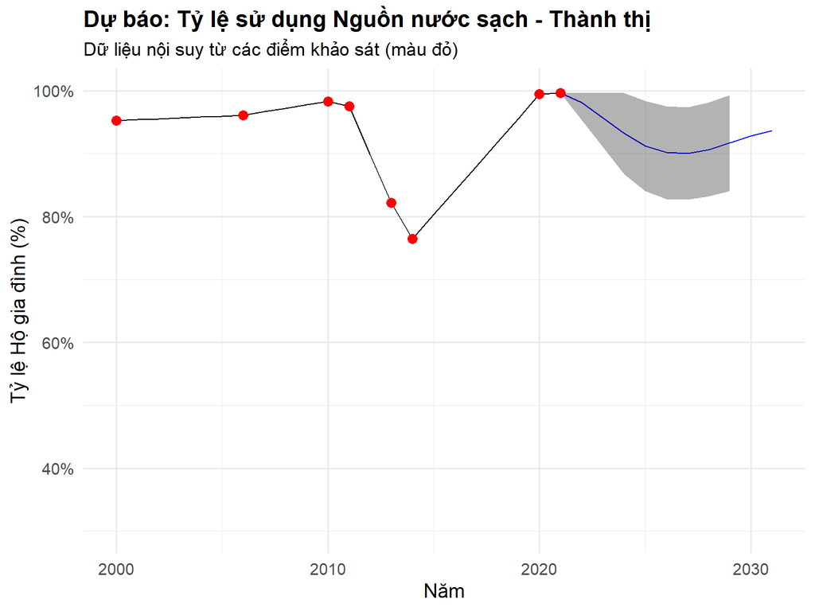

**Diễn giải kết quả:** Mô hình ARIMA(2,0,0)

- Tương tự nông thôn: sau 2021, tỷ lệ dự kiến giảm nhẹ giai đoạn 2022–2026, sau đó phục hồi dần đến 2030.
- Giá trị RMSE = 0.0197 cho thấy mô hình có độ chính xác cao và sai số nhỏ

##### Nhà tiêu - Thành thị

```
##
## **Mô hình ARIMA cho Tỷ lệ tiếp cận Nhà tiêu Hợp vệ sinh - Thành thị**
## Series: ts_object
## ARIMA(0,1,0) with drift
##
## Coefficients:
##        drift
##       0.0064
## s.e.  0.0030
##
## sigma^2 = 0.0001972:  log likelihood = 60.3
## AIC=-116.59   AICc=-115.93   BIC=-114.5
##
## Training set error measures:
##                        ME       RMSE        MAE        MPE     MAPE     MASE
## Training set 3.506885e-05 0.01338808 0.01096481 0.02604016 1.242993 0.913136
##                   ACF1
## Training set 0.1845041
```

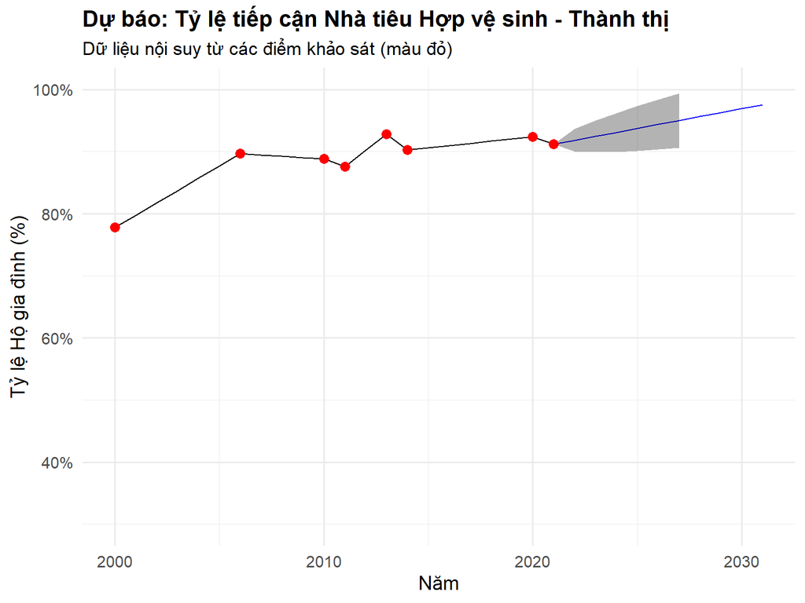

**Diễn giải kết quả:** Mô hình ARIMA(0,1,0) với drift = 0.0064.

→ Dự báo: khu vực thành thị duy trì mức rất cao, gần như toàn bộ hộ dân sử dụng nhà tiêu hợp vệ sinh.

### **2. K**iểm định mối quan hệ giữa Nước sạch và Bệnh Tiêu chảy ở trẻ trong 20 năm

Bảng 8. Bảng tổng hợp Tỷ lệ tiêu chảy theo năm và chất lượng nước

```
## # A tibble: 10 × 4
##     year improved_water diarrhea_rate water_status
##    <dbl>          <dbl>         <dbl> <chr>
##  1  2000              0        0.120  Nước không sạch
##  2  2000              1        0.114  Nước sạch
##  3  2006              0        0.0875 Nước không sạch
##  4  2006              1        0.0808 Nước sạch
##  5  2011              0        0.107  Nước không sạch
##  6  2011              1        0.0688 Nước sạch
##  7  2014              0        0.195  Nước không sạch
##  8  2014              1        0.0850 Nước sạch
##  9  2021              0        0.102  Nước không sạch
## 10  2021              1        0.0737 Nước sạch
```

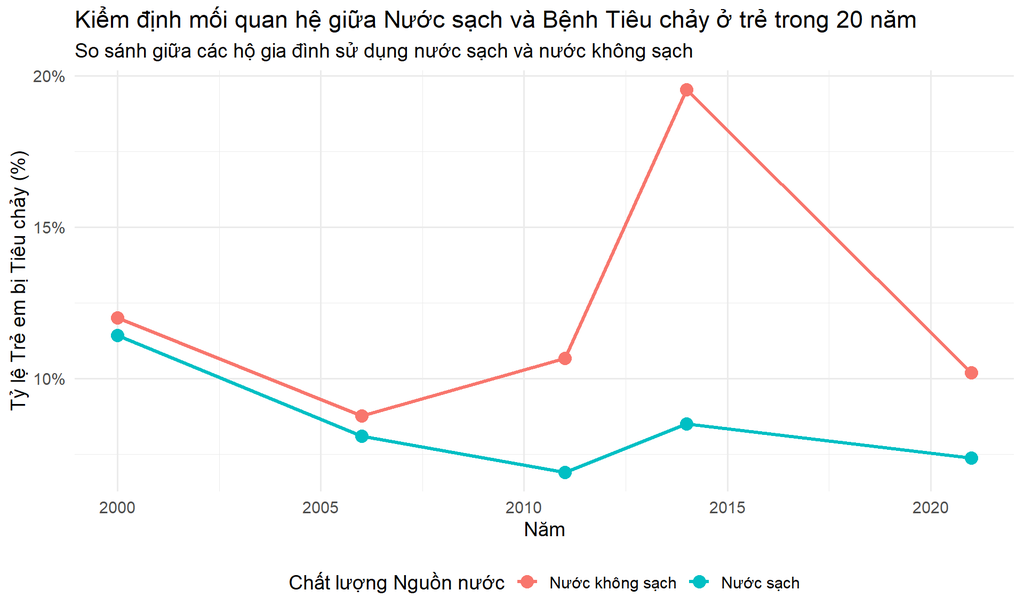

**Diễn giải kết quả:**